# Tugas UAS mandiri

Ibrahim Zaidan

2025-11-21

# Import Data

```r
packages <- c(
  "tidyverse", "readxl", "janitor", "lubridate",
  "stringr", "data.table", "skimr"
)

installed <- rownames(installed.packages())
to_install <- packages[!packages %in% installed]
if(length(to_install) > 0){
  install.packages(to_install)
}

lapply(packages, library, character.only = TRUE)
```

[output not shown]

```r
path_data <- "C:/Users/De Ibrahim/kuliah/sem 5/TPG/Kuliah/Data Proyek Mandiri.xlsx"
data_mentah <- read_excel(path_data)
head(data_mentah)
```

| KabKot | Tahun | Bulan | Produk | Harga | Kategori | KodeBPS | KodeProv | NamaProv |
| --- | --- | --- | --- | --- | --- | --- | --- | --- |
| Kab. Aceh Barat | 2022 | Januari | Beras Premium | 11429 | Beras | 11.05 | 11 | Aceh |
| Kab. Aceh Barat | 2022 | Januari | Beras Medium | 9979 | Beras | 11.05 | 11 | Aceh |
| Kab. Aceh Barat | 2022 | Januari | Bawang Merah | 31000 | Bawang | 11.05 | 11 | Aceh |
| Kab. Aceh Barat | 2022 | Januari | Bawang Putih (Bonggol) | 28636 | Bawang | 11.05 | 11 | Aceh |
| Kab. Aceh Barat | 2022 | Januari | Cabai Merah Keriting | 19409 | Cabai | 11.05 | 11 | Aceh |
| Kab. Aceh Barat | 2022 | Januari | Cabai Rawit Merah | 45706 | Cabai | 11.05 | 11 | Aceh |

# Preprocessing I

Memperbaiki format data yang tidak rapih dan mempersulit analisis kedepannya.

## Pembersihan Kolom dan Tipe Data

```r
data <- data_mentah %>%
clean_names() %>%
  rename(
    Kabupaten_Kota = kab_kot,
    Tahun = tahun,
    Bulan = bulan,
    Produk = produk,
    Harga = harga,
    Kategori = kategori,
    Kode_BPS = kode_bps,
    Kode_Provinsi = kode_prov,
    Nama_Provinsi = nama_prov
) %>%
  mutate(
    across(c(Kabupaten_Kota, Bulan, Produk, Kategori, Nama_Provinsi),
           str_squish),
    Harga = as.numeric(str_replace_all(Harga, "[^0-9]", "")),
    Kode_BPS = as.character(Kode_BPS),
    Kode_Provinsi = as.character(Kode_Provinsi)
)
```

Data sudah rapi, nama kolom distandarisasi, tipe data disesuaikan, dan harga diubah menjadi numerik.

## Bulan mapping

```r
bulan_mapping <- c(
"Januari"="01","Februari"="02","Maret"="03","April"="04",
"Mei"="05","Juni"="06","Juli"="07","Agustus"="08",
"September"="09","Oktober"="10","November"="11","Desember"="12"
)
data <- data %>%
  mutate(
    bulan_num = bulan_mapping[Bulan],
    Tanggal = ymd(paste0(Tahun, "-", bulan_num, "-01"))
)
head(data)
```

| Kabupaten_Kota | Tahun | Bulan | Produk | Harga | Kategori | Kode_BPS | Kode_Provinsi | Nama_Provinsi | bulan_num | Tanggal |
| --- | --- | --- | --- | --- | --- | --- | --- | --- | --- | --- |
| Kab. Aceh Barat | 2022 | Januari | Beras Premium | 11429 | Beras | 11.05 | 11 | Aceh | 01 | 2022-01-01 |
| Kab. Aceh Barat | 2022 | Januari | Beras Medium | 9979 | Beras | 11.05 | 11 | Aceh | 01 | 2022-01-01 |
| Kab. Aceh Barat | 2022 | Januari | Bawang Merah | 31000 | Bawang | 11.05 | 11 | Aceh | 01 | 2022-01-01 |
| Kab. Aceh Barat | 2022 | Januari | Bawang Putih (Bonggol) | 28636 | Bawang | 11.05 | 11 | Aceh | 01 | 2022-01-01 |
| Kab. Aceh Barat | 2022 | Januari | Cabai Merah Keriting | 19409 | Cabai | 11.05 | 11 | Aceh | 01 | 2022-01-01 |
| Kab. Aceh Barat | 2022 | Januari | Cabai Rawit Merah | 45706 | Cabai | 11.05 | 11 | Aceh | 01 | 2022-01-01 |

Menambahkan kolom bulan numerik dan membuat kolom Tanggal dalam format Date untuk analisis time series.

## Imputasi linear interpolation

```r
data <- data %>%
  group_by(Kabupaten_Kota, Produk) %>%
  arrange(Tanggal) %>%
  mutate(
    Harga_Imputed = zoo::na.approx(Harga, na.rm = FALSE),
    Harga_Imputed = zoo::na.locf(Harga_Imputed, na.rm = FALSE),
    Harga_Imputed = zoo::na.locf(Harga_Imputed, fromLast = TRUE, na.rm = FALSE)
) %>%
ungroup()
```

# Preprocessing II

Memperbaiki dan mempersiapkan format data yang ingin dipakai berdasarkan topik yang dipilih.

## Filter Produk

```r
gula <- data %>%
  filter(Produk == "Gula Konsumsi") %>%
  select(Kabupaten_Kota, Tanggal, Harga_Imputed)
gula
```

| Kabupaten_Kota | Tanggal | Harga_Imputed |
| --- | --- | --- |
| Kab. Aceh Barat | 2022-01-01 | 14545.00 |
| Kab. Aceh Barat Daya | 2022-01-01 | 14885.00 |
| Kab. Aceh Besar | 2022-01-01 | 12966.00 |
| Kab. Aceh Jaya | 2022-01-01 | 13100.00 |
| Kab. Aceh Selatan | 2022-01-01 | 14097.00 |
| Kab. Aceh Singkil | 2022-01-01 | 13625.00 |
| Kab. Aceh Tamiang | 2022-01-01 | 13607.00 |
| Kab. Aceh Tengah | 2022-01-01 | 14267.00 |
| Kab. Aceh Tenggara | 2022-01-01 | 14103.00 |
| Kab. Aceh Timur | 2022-01-01 | 13677.00 |

[output cut: 9990 more lines]

Menyaring hanya data gula konsumsi dan menyimpan kolom kabupaten, tanggal, dan harga terimputasi

## Pivot untuk time-series clustering

```r
gula_ts <- gula %>%
  pivot_wider(
    names_from = Kabupaten_Kota,
    values_from = Harga_Imputed
) %>%
  arrange(Tanggal)
gula_ts
```

| Tanggal | Kab. Aceh Barat | Kab. Aceh Barat Daya | Kab. Aceh Besar | Kab. Aceh Jaya | Kab. Aceh Selatan | Kab. Aceh Singkil | Kab. Aceh Tamiang | Kab. Aceh Tengah | Kab. Aceh Tenggara | Kab. Aceh Timur | Kab. Aceh Utara | Kab. Agam | Kab. Alor | Kab. Asahan | Kab. Badung | Kab. Balangan | Kab. Bandung | Kab. Bandung Barat | Kab. Banggai | Kab. Banggai Kepulauan | Kab. Banggai Laut | Kab. Bangka | Kab. Bangka Barat | Kab. Bangka Selatan | Kab. Bangka Tengah | Kab. Bangkalan | Kab. Bangli | Kab. Banjar | Kab. Banjarnegara | … |
| --- | --- | --- | --- | --- | --- | --- | --- | --- | --- | --- | --- | --- | --- | --- | --- | --- | --- | --- | --- | --- | --- | --- | --- | --- | --- | --- | --- | --- | --- | --- |
| 2022-01-01 | 14545 | 14885 | 12966 | 13100 | 14097 | 13625 | 13607 | 14267 | 14103 | 13677 | 13300 | 14000 | 15250 | 13000 | 13000 | 14250 | 13217 | 13371 | 15000 | 14452 | 15000 | 13355 | 13113 | 13000 | 13967 | 13650 | 13468 | 13983 | 13241 | … |
| 2022-02-01 | 14857 | 15000 | 13000 | 13786 | 14071 | 14077 | 14020 | 15000 | 15000 | 14000 | 14000 | 14741 | 15704 | 13250 | 13643 | 14036 | 13389 | 13464 | 15179 | 16000 | 15000 | 14000 | 13548 | 12964 | 14000 | 13560 | 13982 | 14500 | 13500 | … |
| 2022-03-01 | 15000 | 15192 | 14310 | 14000 | 14042 | 14214 | 14433 | 15000 | 15000 | 14000 | 14032 | 14484 | 14958 | 13500 | 14000 | 14468 | 13500 | 13468 | 15333 | 16000 | 15233 | 14000 | 14315 | 14032 | 14138 | 14160 | 14000 | 14597 | 13817 | … |
| 2022-04-01 | 15120 | 15423 | 15000 | 14000 | 14067 | 15037 | 15000 | 15000 | 15000 | 14167 | 14207 | 15000 | 15000 | 13655 | 14100 | 15000 | 13583 | 13500 | 16000 | 16846 | 16000 | 14483 | 14417 | 15000 | 14889 | 14052 | 14000 | 15033 | 14276 | … |
| 2022-05-01 | 15000 | 15053 | 15000 | 14613 | 14345 | 15000 | 15000 | 15000 | 15000 | 14000 | 15000 | 14815 | 15000 | 14138 | 14000 | 15052 | 14500 | 13867 | 16096 | 17000 | 16000 | 14468 | 13989 | 15000 | 14548 | 14000 | 14000 | 15000 | 14500 | … |
| 2022-06-01 | 14907 | 14875 | 14948 | 14993 | 14219 | 15074 | 14983 | 14989 | 15111 | 14672 | 15093 | 14938 | 14957 | 14519 | 14295 | 14964 | 14537 | 14196 | 15704 | 16480 | 15717 | 14069 | 14100 | 14641 | 14391 | 13962 | 14143 | 14724 | 14462 | … |
| 2022-07-01 | 15033 | 14984 | 15033 | 15050 | 13877 | 14103 | 14517 | 14217 | 14533 | 14017 | 14100 | 14883 | 14982 | 13967 | 14069 | 14111 | 14431 | 14065 | 15857 | 16414 | 15250 | 14032 | 13745 | 14032 | 14854 | 13054 | 13968 | 14067 | 14517 | … |
| 2022-08-01 | 14967 | 15000 | 15000 | 15000 | 13800 | 14000 | 14000 | 14000 | 14533 | 14000 | 14000 | 14533 | 15000 | 14000 | 14000 | 14000 | 14172 | 14000 | 16000 | 16283 | 15000 | 14000 | 13687 | 14000 | 14893 | 13172 | 13050 | 13931 | 14350 | … |
| 2022-09-01 | 15000 | 15000 | 14100 | 15000 | 13880 | 14030 | 14000 | 14000 | 15000 | 14000 | 14000 | 14000 | 15000 | 14000 | 14000 | 14000 | 14333 | 14000 | 16000 | 16000 | 15000 | 14000 | 13700 | 14000 | 14400 | 12500 | 13000 | 14000 | 14086 | … |
| 2022-10-01 | 14097 | 15000 | 14000 | 15000 | 13800 | 14000 | 14000 | 14000 | 15000 | 14000 | 14000 | 14167 | 15000 | 14000 | 14000 | 14000 | 14500 | 14000 | 16000 | 15613 | 15000 | 14000 | 13700 | 14000 | 14185 | 12810 | 13000 | 13968 | 13293 | … |

[output cut: 36 more lines]

Mengubah data dari format panjang (long) menjadi format lebar (wide) sehingga setiap Kabupaten/Kota menjadi kolom berisi harga gula per tanggal.

## Matrix awal

```r
ts_mat <- gula_ts %>% select(-Tanggal) %>% as.matrix()
```

Mengubah data gula menjadi matriks agar data dapat diproses oleh algoritma K-Means yang membutuhkan input berupa matriks numerik.

# Atasi kolom bermasalah

## Hapus kolom NA

```r
ts_mat <- ts_mat[, colSums(is.na(ts_mat)) < nrow(ts_mat)]
```

Hapus kolom berisi NA yang terdeteksi

## Interpolasi forward/backward

```r
ts_mat <- apply(ts_mat, 2, function(x){
  x <- zoo::na.approx(x, na.rm = FALSE)
  x <- zoo::na.locf(x, na.rm = FALSE)
  x <- zoo::na.locf(x, fromLast = TRUE, na.rm = FALSE)
  return(x)
})
```

Melakukan Interpolasi untuk kolom yang masih ada sisa NA

## Hapus NA sisa

```r
ts_mat <- ts_mat[, colSums(is.na(ts_mat)) == 0]
```

Hapus kolom yang masih mengandung NA setelah semua metode

## Hapus kolom dengan sd = 0

```r
sd_col <- apply(ts_mat, 2, sd)
ts_mat <- ts_mat[, sd_col > 0]
```

variabel konstan bikin NaN saat scale

# Clustering

## Transpose matriks

```r
ts_mat_t <- t(ts_mat)
```

Mentranspose matriks sehingga baris menjadi daerah dan kolom menjadi waktu.

## scale data

```r
ts_scaled <- scale(ts_mat_t)
```

Menskalakan data untuk persiapan clustering.

## Menentukan jumlah cluster

```r
library(factoextra)
```

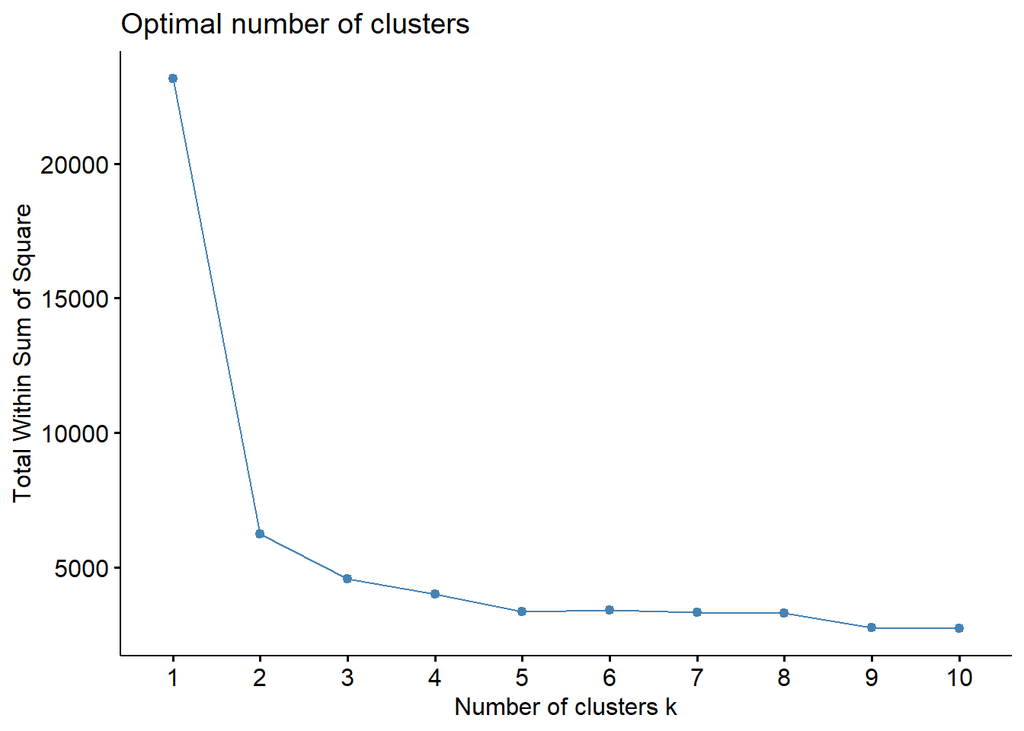

```r
fviz_nbclust(ts_scaled, kmeans, method="wss")
```

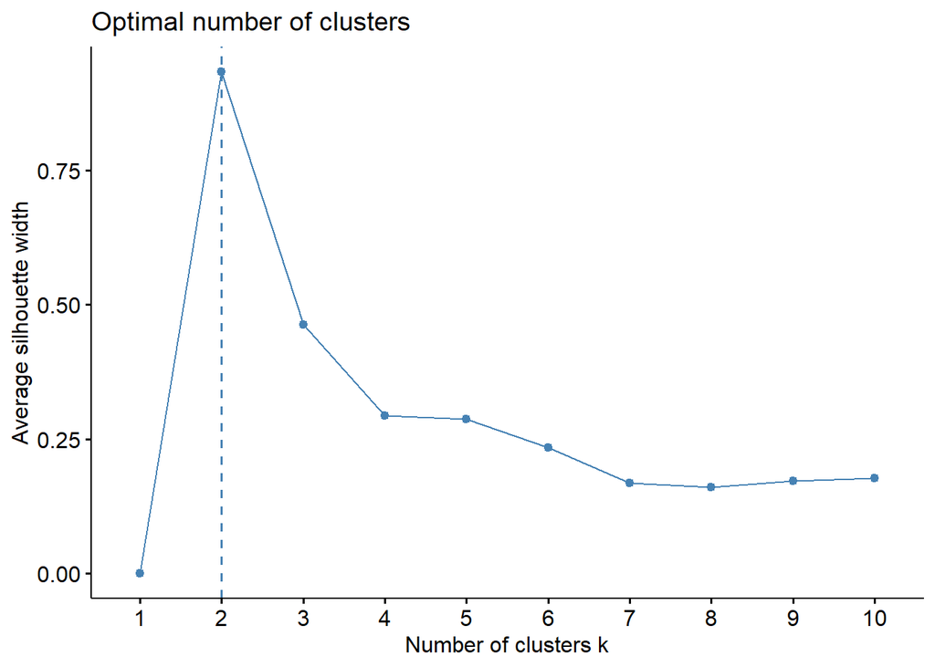

```r
fviz_nbclust(ts_scaled, kmeans, method="silhouette")
```

Grafik menunjukkan k=2 sebagai jumlah cluster optimal.

## K-Means

```r
set.seed(1401231099) # karena NIM saya G1401231099
k_res <- kmeans(ts_scaled, centers = 2, nstart = 25)
table(k_res$cluster)
```

```
##
##   1   2
## 498   6
```

Terdapat 498 daerah di cluster 1 dan 6 daerah di cluster 2.

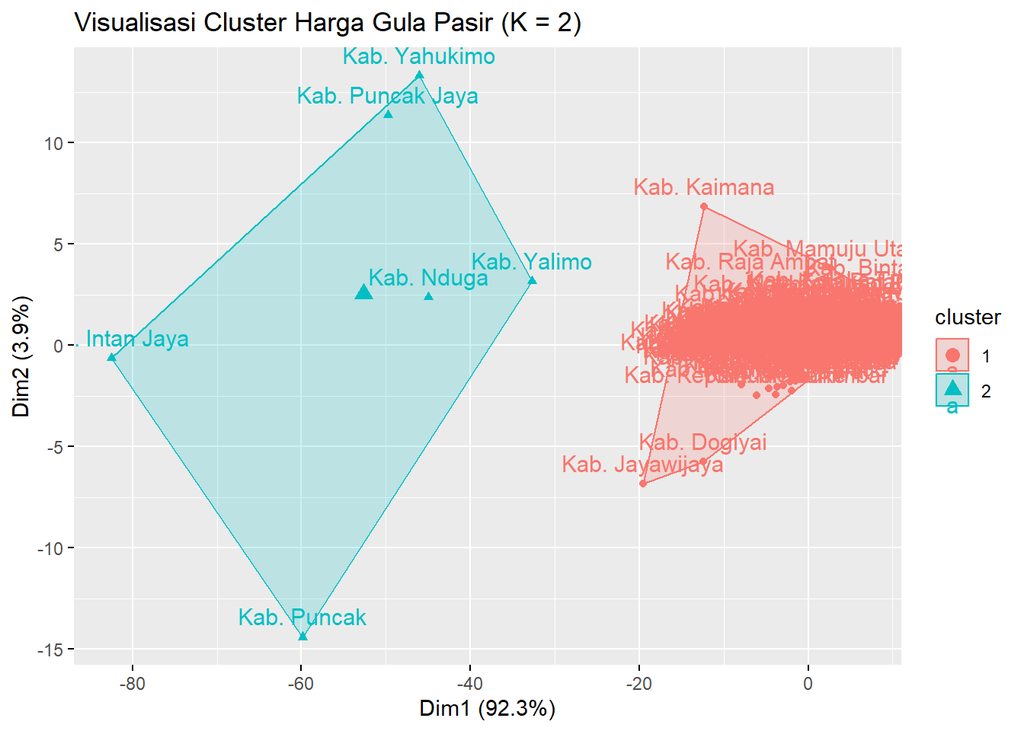

```r
library(factoextra)
fviz_cluster(k_res, data = ts_scaled,
             main = "Visualisasi Cluster Harga Gula Pasir (K = 2)")
```

cluster 1 wilayah-wilayah dengan harga gula cenderung stabil.

cluster 2 wilayah-wilayah dengan harga gula tinggi (ekstrem).

# Analisis statistik

## daftar anggota tiap cluster

```r
cluster_member <- data.frame(
  Daerah = rownames(ts_scaled),
  Cluster = k_res$cluster
)
cluster_member
```

|  | Daerah | Cluster |
| --- | --- | --- |
| Kab. Aceh Barat | Kab. Aceh Barat | 1 |
| Kab. Aceh Barat Daya | Kab. Aceh Barat Daya | 1 |
| Kab. Aceh Besar | Kab. Aceh Besar | 1 |
| Kab. Aceh Jaya | Kab. Aceh Jaya | 1 |
| Kab. Aceh Selatan | Kab. Aceh Selatan | 1 |
| Kab. Aceh Singkil | Kab. Aceh Singkil | 1 |
| Kab. Aceh Tamiang | Kab. Aceh Tamiang | 1 |
| Kab. Aceh Tengah | Kab. Aceh Tengah | 1 |
| Kab. Aceh Tenggara | Kab. Aceh Tenggara | 1 |
| Kab. Aceh Timur | Kab. Aceh Timur | 1 |

[output cut: 494 more lines]

```r
cluster_member %>%
  filter(Cluster == 2)
```

|  | Daerah | Cluster |
| --- | --- | --- |
| Kab. Puncak Jaya | Kab. Puncak Jaya | 2 |
| Kab. Puncak | Kab. Puncak | 2 |
| Kab. Intan Jaya | Kab. Intan Jaya | 2 |
| Kab. Nduga | Kab. Nduga | 2 |
| Kab. Yahukimo | Kab. Yahukimo | 2 |
| Kab. Yalimo | Kab. Yalimo | 2 |

Membuat tabel yang mencocokkan setiap daerah dengan cluster hasil K-Means agar kita tahu daerah mana masuk pola harga yang mana.

## rata-rata level harga tiap cluster

```r
clusters <- k_res$cluster
cluster_mean_level <- data.frame(
  Daerah = colnames(ts_mat),
  Cluster = clusters
) %>%
  left_join(
    data.frame(
      Daerah = colnames(ts_mat),
      RataRataHarga = colMeans(ts_mat)
    ),
    by = "Daerah"
  ) %>%
  group_by(Cluster) %>%
  summarise(Mean_Level = mean(RataRataHarga))
cluster_mean_level
```

| Cluster | Mean_Level |
| --- | --- |
| 1 | 16400.58 |
| 2 | 38001.78 |

Walaupun cluster 1 sebanyak 498 daerah, rata-rata harganya masih jauh lebih rendah dari cluster 2.

## variabilitas harga tiap cluster

```r
cluster_volatility <- data.frame(
  Daerah = colnames(ts_mat),
  Cluster = clusters
) %>%
  left_join(
    data.frame(t(apply(ts_mat, 2, sd)), check.names = FALSE) %>%
      pivot_longer(everything(), names_to="Daerah", values_to="Volatility"),
    by="Daerah"
  ) %>%
  group_by(Cluster) %>%
  summarise(Volatility_Avg = mean(Volatility))
cluster_volatility
```

| Cluster | Volatility_Avg |
| --- | --- |
| 1 | 1865.005 |
| 2 | 3303.793 |

Cluster 2 tidak hanya tinggi di harga, tetapi juga tinggi di volatilitas.

# Kesimpulan

Setelah saya cari tau, ternyata 6 daerah tersebut semuanya terletak di Pegunungan Tengah Papua, di mana tempatnya sangat terisolasi, topografinya pegunungan/lembah, dan bahkan arus barang masuk melalui angkutan udara. kabupaten-kabupaten ini sangat sulit dijangkau, sehingga distribusi barang (termasuk gula) ke sana sangat mahal dan rumit.